# PredictifyR | Word Prediction Model

John James

14 April, 2017

# Abstract

# Introduction

Word prediction language models are essential components within a range of natural language processing (NLP) applications such as Augmented and Alternative Communication (AAC), statistical machine translation, speech recognition (Bahl, Jelinek, and Mercer 1983), handwriting recognition, word-sense disambiguation, spelling correction and predictive text entry. Mobile device applications, which are the focus of this report, require language models that are accurate, fast, and compact. The statistical n-gram language model is the dominant technology; yet, more sophisticated models are being developed which are able to exploit other natural language phenomena, including syntactic, semantic, and morphological structures (Cavalieri, Bastos-Filho, and Palazuelos-Cagigas 2015). Innovative interpolation methods to integrate language models are also being developed with interesting results.

Through a systematic evaluation of selected word prediction strategies, algorithms and language models, this work seeks to determine which algorithms best meet the performance imperatives of the mobile device predictive text entry application. Statistical n-Gram techniques, syntactic modeling approaches, semantic-based models, and classification-based techniques were evaluated from prediction accuracy, model size, and speed perspectives.

The remainder of this section provides an introduction to probabilistic word prediction and n-Gram language models. Section 2 surveys related work in terms of the best performing n-Gram based-models and smoothing techniques, models which integrate syntactic information, semantic approaches and learning-classification based approaches. Section 3 reveals the details of the experimental methodology including corpus analysis, preprocessing, and sampling, as well as language model implementation and parameter selection. Section 4 outlines the results of the study and finally, section 5 summarizes the most important conclusions of the work.

## Probabilistic Word Prediction

### Evaluating Language Models

Multiplying all the probabilities of all the N-gram together can result in numeric underflow. Instead one works in log space, adding the log of the probabilities together, then taking the average of the sum of the log probabilities over the entire corpus. Lastly, we take the negative of the corpus log probability and raise that to the power of 2, resulting in a positive number. The final equation is as follows:

$$Perplexity = 2^{-{1/N}{\displaystyle\sum_{i=1}^N{log p({s_i})}}}$$

Note that perplexity calculation fails with zeros in the denominator if a word or N-gram sequence from the test set doesn’t occur in the training set. The next section provides techniques for dealing with such out-of-vocabulary (OOV) words and sequences.

### Smoothing

Smoothing refers to a class of techniques to deal with unseen events by adjusting the maximum likelihood estimates of low probabilities upward and high probabilities downward. This not only prevents zero probabilities, but improves the predictive accuracy of the language model overall. One of the simplest smoothing techniques is Add-k smoothing [Lidstone (1920);doi:10.1093/mind/XLI.164.409; Jeffreys61], in which the count of each n-gram is increased by $\delta$, typically $0 < \delta \leq 1$. Good-Turing smoothing estimates the probability of unseen events by reallocating the probability mass of n-grams that occur $r + 1$ times in the training data to the n-grams that occur $r$ times (Good 1953). Since the algorithm doesn’t include the combination of higher-order models with lower-order models, it is typically used with other smoothing techniques (Chen and Goodman 1996). Jelinek-Mercer smoothing interpolates higher-order maximum likely estimate probabilities with lower-order probabilities, where the interpolation factor $\lambda_{w_{i-n+1}^{i-1}}$ is estimated for each history using held-out data (Jelinek and Mercer 1980). Katz smoothing extends the Good-Turing estimate by adding the combination of higher-order models with lower-order models (Katz 1987). Witten-Bell smoothing (Bell, Cleary, and Witten 1990) extends Jelinek-Mercer smoothing in that the nth-order smoothed model is defined recursively as a linear interpolation between the nth-order maximum likelihood model and the ($n-1$)th-order smoothed model. The interpolation parameter $\lambda_{w_{i-n+1}^{i-1}}$, is computed by counting the number of unique words that follow the history $w_{i-n+1}^{i-1}$. Absolute Discounting (H. Ney, Essen, and Kneser 1994a), ), like Jelinek-Mercer smoothing, combines higher and lower-order models; however, instead of multiplying the higher-order maximum-likelihood distribution by a factor $\lambda_{w_{i-n+1}^{i-1}}$, a discount factor $D\leq1$ is subtracted from each non-zero count. Lastly, Kneser-Ney smoothing (Kneser and Ney 1995) is an extension of absolute discounting where the lower-order distribution is proportional not with the count of the n-gram, but the number of unique words that follow the n-gram in the training text. Since this project implemented Modified Kneser-Ney (Chen and Goodman 1996), absolute discounting, its predecessor, Kneser-Ney, and Modified Kneser-Ney are covered in more detail below.

#### Absolute Discounting

Absolute discounting (H. Ney, Essen, and Kneser 1994b) subtracts a fixed discount $d$ typically less than 1, from each count. Very high counts have good probability estimates and are not affected by the discount as much as smaller counts with relatively unreliable estimates. Interpolated absolute discounting improves the algorithm by interpolating lower order models as follows:

$$P_{abs}(w_i | w_{i-n+1}^{i-1}) = \frac{max\left\{c(w_{i-n+1}^{i})-D,0\right\}} {c(w_{i-n+1}^{i-1})}+\lambda(w_{i-n+1}^{i-1})P_{abs}(w_i | w_{i-n+2}^{i-1})$$
To force the distribution to sum to 1:
$$\lambda(w_{i-n+1}^{i-1}) = \frac{D}{{c(w_{i-n+1}^{i-1})}} N_{1+}(w_{i-n+1}^{i-1}\bullet)$$
where $N_{1+}$ is the number of words that have one or more counts and $N_{1+}(w_{i-n+1}^{i-1}\bullet) = |\left\{w_i : c(w_{i-n+1}^{i} w_i) > 0\right\}|$ is the number of unique words that follow the sequence. $D$ is estimated as follows:
$$D = \frac{n_1}{n_1 + 2n_2}$$
where $n_1$ and $n_2$ are the total number of n-grams with exactly one and two counts, respectively (Chen and Goodman 1996).

#### Kneser-Ney Smoothing

Kneser-Ney smoothing improves on interpolated absolute discounting by constructing the lower-order distribution that is combined with the higher-order distribution in a novel manner. In interpolated absolute discounting, the lower-order distribution is based upon a smoothed version of the lower-order maximum likelihood estimation. Rather than considering lower-order n-gram frequencies, the Kneser-Ney algorithm bases the lower-order distribution on the number of n-gram prefixes the word follows. In other words, the algorithm counts how often the word exists as a novel continuation of the n-gram prefix (Chen and Goodman 1996). There are three Kneser-Ney formulations: one for the **highest** order N-gram distributions $n$ where $n=N$, a second for **higher** distributions $n$ where $1 < n < N$, and a third for the unigram distribution $n = 1$. The recursive formulation for the **highest** order distribution is as follows:

$$P_{KN}(w_i | w_{i-n+1}^{i-1}) = \frac{max\left\{c(w_{i-n+1}^{i})-D,0\right\}}{ c(w_{i-n+1}^{i-1})}+\frac{D}{c(w_{i-n+1}^{i-1})} N_{1+}(w_{i-n+1}^{i-1}\bullet)P_{KN}(w_i | w_{i-n+2}^{i-1})$$
where $\begin{equation}N_{1+}(w_{i-n+1}^{i-1}\bullet) = |\left\{w_i : c(w_{i-n+1}^{i} w_i) > 0\right\}|\end{equation}$

The recursive formulation for the **higher** order distribution $n$ where $1 < n < N$ is as follows:

$$\begin{equation}
P_{KN}(w_i | w_{i-n+1}^{i-1}) = \frac{max\left\{N_{1+}(\bullet w_{i-n+1}^{i})-D,0\right\}}{N_{1+}(\bullet w_{i-n+1}^{i-1}\bullet)}+\frac{D}{N_{1+}(\bullet w_{i-n+1}^{i-1}\bullet)} N_{1+}(w_{i-n+1}^{i-1}\bullet)P_{KN}(w_i | w_{i-n+2}^{i-1})
\end{equation}$$
where $\begin{equation}N_{1+}(w_{i-n+1}^{i}\bullet) = |\left\{w_{i-n} : c(w_{i-n}^{i} w_i) > 0\right\}|\end{equation}$ $\begin{equation}N_{1+}(\bullet w_{i-n+1}^{i-1}\bullet) = |\left\{(w_{i-n}, w_i) : c(w_{i-n}^{i}) > 0\right\}| = \displaystyle\sum_{w_i} N_{1+}(\bullet w_{i-n+1}^{i})\end{equation}$

The formulation for the **lowest** unigram distribution is as follows:

$$\begin{equation}
P_{KN}(w_i) = \frac{N_{1+}(\bullet w_{i})}{N_{1+}(\bullet\bullet)}
\end{equation}$$
where $N_{1+}(\bullet w_i) = |\left\{w_{i-1} : c(w_{i-1}^{i}) > 0\right\}|$ $N_{1+}(\bullet \bullet) = |\left\{(w_{i-1}, w_i) : c(w_{i-1}^{i}) > 0\right\}| = \displaystyle\sum_{w_i} N_{1+}(\bullet w_{i})$

#### Modified Kneser-Ney Smoothing

Modified Kneser-Ney Smoothing is the best performing version of the group. Instead of using a single discount $D$ for all non-zero counts, this version uses three different discount parameters $D_{n,1}$,$D_{n,2}$, and $D_{n,3+}$ for each N-Gram order ($1 < n \leq N$). The equation for the **higher** order N-Grams is as follows:

$$\begin{equation}
P_{MKN}(w_i | w_{i-n+1}^{i-1}) = \frac{max\left\{N_{1+}(\bullet w_{i-n+1}^{i})-D_n(c(w_{i-n+1}^i)),0\right\}}{N_{1+}(\bullet w_{i-n+1}^{i-1}\bullet)}+\lambda_{low}(w_{i-n+1}^{i-1})P_{MKN}(w_i | w_{i-n+2}^{i-1})
\end{equation}$$

where

$$D_n(c) =
\begin{cases}
0 & \quad \text{if } c=0\\
D_{n,1} & \quad \text{if } c=1\\
D_{n,2} & \quad \text{if } c=2\\
D_{n,3+} & \quad \text{if } c\geq3\\
\end{cases}$$
The normalized discount $\lambda_{low}(w_{i-n+1}^{i-1})$ for the **higher** order N-Gram distributions is:
$$\lambda_{low}(w_{i-n+1}^{i-1}) = \frac{D_{n,1} N_1(w_{i-n+1}^{i-1}\bullet) + D_{n,2} N_2(w_{i-n+1}^{i-1}\bullet) + D_{n,3+} N_{3+}(w_{i-n+1}^{i-1}\bullet)}{N_{1+}(\bullet w_{i-n+1}^{i-1}\bullet)}$$
where $N_1(w_{i-n+1}^{i-1}\bullet)$, $N_2(w_{i-n+1}^{i-1}\bullet)$, and $N_{3+}(w_{i-n+1}^{i-1}\bullet)$ are the unique one word contexts in which the sequence appears, precisely once, twice, or 3 or more times, respectively.

Analogously, the equation for the **highest** order N-Gram distribution uses absolute counts for the highest level discounted probability estimate and is as follows:

$$\begin{equation}
P_{MKN}(w_i | w_{i-n+1}^{i-1}) = \frac{max\left\{c(w_{i-n+1}^i)-D_n(c(w_{i-n+1}^i)),0\right\}}{c(w_{i-n+1}^i)}+\lambda_{high}(w_{i-n+1}^{i-1})P_{MKN}(w_i | w_{i-n+2}^{i-1})
\end{equation}$$

where the normalized discount $\lambda_{high}(w_{i-n+1}^{i-1})$ for the **highest** order N-Gram distributions is:

$$\lambda_{high}(w_{i-n+1}^{i-1}) = \frac{D_{n,1} N_1(w_{i-n+1}^{i-1}\bullet) + D_{n,2} N_2(w_{i-n+1}^{i-1}\bullet) + D_{n,3+} N_{3+}(w_{i-n+1}^{i-1}\bullet)}{c(w_{i-n+1}^{i-1})}$$

## Incorporating Semantic Knowledge

# Related Work

In this section, several approaches to word prediction are surveyed. This is not intended to be an exhaustive review, rather, the focus is on novel approaches and those considered state-of-the-art in word prediction. First, statistical n-gram based approaches and language models (LMs) are examined. Then, language models that incorporate syntactice and semantic knowledge are considered.

## Probabilistic Word Prediction

This section outlines the primary word prediction algorithms and systems that implement them.

### Probabilistic Word Prediction Algorithms

#### Evaluating Language Models

Multiplying all the probabilities of all the N-gram together can result in numeric underflow. Instead one works in log space, adding the log of the probabilities together, then taking the average of the sum of the log probabilities over the entire corpus. Lastly, we take the negative of the corpus log probability and raise that to the power of 2, resulting in a positive number. The final equation is as follows:

$$Perplexity = 2^{-{1/N}{\displaystyle\sum_{i=1}^N{log p({s_i})}}}$$

Note that perplexity calculation fails with zeros in the denominator if a word or N-gram sequence from the test set doesn’t occur in the training set. The next section provides techniques for dealing with such out-of-vocabulary (OOV) words and sequences.

#### Smoothing

Smoothing refers to a class of techniques to deal with unseen events by adjusting the maximum likelihood estimates of low probabilities upward and high probabilities downward. This not only prevents zero probabilities, but improves the predictive accuracy of the language model overall. One of the simplest smoothing techniques is Add-k smoothing [Lidstone (1920);doi:10.1093/mind/XLI.164.409; Jeffreys61], in which the count of each n-gram is increased by $\delta$, typically $0 < \delta \leq 1$. Good-Turing smoothing estimates the probability of unseen events by reallocating the probability mass of n-grams that occur $r + 1$ times in the training data to the n-grams that occur $r$ times (Good 1953). Since the algorithm doesn’t include the combination of higher-order models with lower-order models, it is typically used with other smoothing techniques (Chen and Goodman 1996). Jelinek-Mercer smoothing interpolates higher-order maximum likely estimate probabilities with lower-order probabilities, where the interpolation factor $\lambda_{w_{i-n+1}^{i-1}}$ is estimated for each history using held-out data (Jelinek and Mercer 1980). Katz smoothing extends the Good-Turing estimate by adding the combination of higher-order models with lower-order models (Katz 1987). Witten-Bell smoothing (Bell, Cleary, and Witten 1990) extends Jelinek-Mercer smoothing in that the nth-order smoothed model is defined recursively as a linear interpolation between the nth-order maximum likelihood model and the ($n-1$)th-order smoothed model. The interpolation parameter $\lambda_{w_{i-n+1}^{i-1}}$, is computed by counting the number of unique words that follow the history $w_{i-n+1}^{i-1}$. Absolute Discounting (H. Ney, Essen, and Kneser 1994a), ), like Jelinek-Mercer smoothing, combines higher and lower-order models; however, instead of multiplying the higher-order maximum-likelihood distribution by a factor $\lambda_{w_{i-n+1}^{i-1}}$, a discount factor $D\leq1$ is subtracted from each non-zero count. Lastly, Kneser-Ney smoothing (Kneser and Ney 1995) is an extension of absolute discounting where the lower-order distribution is proportional not with the count of the n-gram, but the number of unique words that follow the n-gram in the training text. Since this project implemented Modified Kneser-Ney (Chen and Goodman 1996), absolute discounting, its predecessor, Kneser-Ney, and Modified Kneser-Ney are covered in more detail below.

##### Absolute Discounting

Absolute discounting (H. Ney, Essen, and Kneser 1994b) subtracts a fixed discount $d$ typically less than 1, from each count. Very high counts have good probability estimates and are not affected by the discount as much as smaller counts with relatively unreliable estimates. Interpolated absolute discounting improves the algorithm by interpolating lower order models as follows:

$$P_{abs}(w_i | w_{i-n+1}^{i-1}) = \frac{max\left\{c(w_{i-n+1}^{i})-D,0\right\}} {c(w_{i-n+1}^{i-1})}+\lambda(w_{i-n+1}^{i-1})P_{abs}(w_i | w_{i-n+2}^{i-1})$$
To force the distribution to sum to 1:
$$\lambda(w_{i-n+1}^{i-1}) = \frac{D}{{c(w_{i-n+1}^{i-1})}} N_{1+}(w_{i-n+1}^{i-1}\bullet)$$
where $N_{1+}$ is the number of words that have one or more counts and $N_{1+}(w_{i-n+1}^{i-1}\bullet) = |\left\{w_i : c(w_{i-n+1}^{i} w_i) > 0\right\}|$ is the number of unique words that follow the sequence. $D$ is estimated as follows:
$$D = \frac{n_1}{n_1 + 2n_2}$$
where $n_1$ and $n_2$ are the total number of n-grams with exactly one and two counts, respectively (Chen and Goodman 1996).

##### Kneser-Ney Smoothing

Kneser-Ney smoothing improves on interpolated absolute discounting by constructing the lower-order distribution that is combined with the higher-order distribution in a novel manner. In interpolated absolute discounting, the lower-order distribution is based upon a smoothed version of the lower-order maximum likelihood estimation. Rather than considering lower-order n-gram frequencies, the Kneser-Ney algorithm bases the lower-order distribution on the number of n-gram prefixes the word follows. In other words, the algorithm counts how often the word exists as a novel continuation of the n-gram prefix (Chen and Goodman 1996). There are three Kneser-Ney formulations: one for the **highest** order N-gram distributions $n$ where $n=N$, a second for **higher** distributions $n$ where $1 < n < N$, and a third for the unigram distribution $n = 1$. The recursive formulation for the **highest** order distribution is as follows:

$$P_{KN}(w_i | w_{i-n+1}^{i-1}) = \frac{max\left\{c(w_{i-n+1}^{i})-D,0\right\}}{ c(w_{i-n+1}^{i-1})}+\frac{D}{c(w_{i-n+1}^{i-1})} N_{1+}(w_{i-n+1}^{i-1}\bullet)P_{KN}(w_i | w_{i-n+2}^{i-1})$$
where $\begin{equation}N_{1+}(w_{i-n+1}^{i-1}\bullet) = |\left\{w_i : c(w_{i-n+1}^{i} w_i) > 0\right\}|\end{equation}$

The recursive formulation for the **higher** order distribution $n$ where $1 < n < N$ is as follows:

$$\begin{equation}
P_{KN}(w_i | w_{i-n+1}^{i-1}) = \frac{max\left\{N_{1+}(\bullet w_{i-n+1}^{i})-D,0\right\}}{N_{1+}(\bullet w_{i-n+1}^{i-1}\bullet)}+\frac{D}{N_{1+}(\bullet w_{i-n+1}^{i-1}\bullet)} N_{1+}(w_{i-n+1}^{i-1}\bullet)P_{KN}(w_i | w_{i-n+2}^{i-1})
\end{equation}$$
where $\begin{equation}N_{1+}(w_{i-n+1}^{i}\bullet) = |\left\{w_{i-n} : c(w_{i-n}^{i} w_i) > 0\right\}|\end{equation}$ $\begin{equation}N_{1+}(\bullet w_{i-n+1}^{i-1}\bullet) = |\left\{(w_{i-n}, w_i) : c(w_{i-n}^{i}) > 0\right\}| = \displaystyle\sum_{w_i} N_{1+}(\bullet w_{i-n+1}^{i})\end{equation}$

The formulation for the **lowest** unigram distribution is as follows:

$$\begin{equation}
P_{KN}(w_i) = \frac{N_{1+}(\bullet w_{i})}{N_{1+}(\bullet\bullet)}
\end{equation}$$
where $N_{1+}(\bullet w_i) = |\left\{w_{i-1} : c(w_{i-1}^{i}) > 0\right\}|$ $N_{1+}(\bullet \bullet) = |\left\{(w_{i-1}, w_i) : c(w_{i-1}^{i}) > 0\right\}| = \displaystyle\sum_{w_i} N_{1+}(\bullet w_{i})$

##### Modified Kneser-Ney Smoothing

Modified Kneser-Ney Smoothing is the best performing version of the group. Instead of using a single discount $D$ for all non-zero counts, this version uses three different discount parameters $D_{n,1}$,$D_{n,2}$, and $D_{n,3+}$ for each N-Gram order ($1 < n \leq N$). The equation for the **higher** order N-Grams is as follows:

$$\begin{equation}
P_{MKN}(w_i | w_{i-n+1}^{i-1}) = \frac{max\left\{N_{1+}(\bullet w_{i-n+1}^{i})-D_n(c(w_{i-n+1}^i)),0\right\}}{N_{1+}(\bullet w_{i-n+1}^{i-1}\bullet)}+\lambda_{low}(w_{i-n+1}^{i-1})P_{MKN}(w_i | w_{i-n+2}^{i-1})
\end{equation}$$

where

$$D_n(c) =
\begin{cases}
0 & \quad \text{if } c=0\\
D_{n,1} & \quad \text{if } c=1\\
D_{n,2} & \quad \text{if } c=2\\
D_{n,3+} & \quad \text{if } c\geq3\\
\end{cases}$$
The normalized discount $\lambda_{low}(w_{i-n+1}^{i-1})$ for the **higher** order N-Gram distributions is:
$$\lambda_{low}(w_{i-n+1}^{i-1}) = \frac{D_{n,1} N_1(w_{i-n+1}^{i-1}\bullet) + D_{n,2} N_2(w_{i-n+1}^{i-1}\bullet) + D_{n,3+} N_{3+}(w_{i-n+1}^{i-1}\bullet)}{N_{1+}(\bullet w_{i-n+1}^{i-1}\bullet)}$$
where $N_1(w_{i-n+1}^{i-1}\bullet)$, $N_2(w_{i-n+1}^{i-1}\bullet)$, and $N_{3+}(w_{i-n+1}^{i-1}\bullet)$ are the unique one word contexts in which the sequence appears, precisely once, twice, or 3 or more times, respectively.

Analogously, the equation for the **highest** order N-Gram distribution uses absolute counts for the highest level discounted probability estimate and is as follows:

$$\begin{equation}
P_{MKN}(w_i | w_{i-n+1}^{i-1}) = \frac{max\left\{c(w_{i-n+1}^i)-D_n(c(w_{i-n+1}^i)),0\right\}}{c(w_{i-n+1}^i)}+\lambda_{high}(w_{i-n+1}^{i-1})P_{MKN}(w_i | w_{i-n+2}^{i-1})
\end{equation}$$

where the normalized discount $\lambda_{high}(w_{i-n+1}^{i-1})$ for the **highest** order N-Gram distributions is:

$$\lambda_{high}(w_{i-n+1}^{i-1}) = \frac{D_{n,1} N_1(w_{i-n+1}^{i-1}\bullet) + D_{n,2} N_2(w_{i-n+1}^{i-1}\bullet) + D_{n,3+} N_{3+}(w_{i-n+1}^{i-1}\bullet)}{c(w_{i-n+1}^{i-1})}$$

Next, language model toolkits that implement these algorithms are introduced.

### Probabilistic Word Prediction Algorithms

#### CMU-Cambridge Statistical Language Modeling Toolkit

Originally released in 1994, by Philip Clarkson of Cambridge University and Ronald Rosenfeld of Carnegie Melon University, the CMU-Cambridge Statistical Language Model Toolkit is a collection of Unix software tools for developing and testing traditional bigram and trigram language models [Clarkson1997]. It now supports $N$-gram models for any value of $N$, Good-Turing [10.2307/2333344] discounting with backoff, linear discounting, absolute discounting, and Witten-Bell [Witten:2006:ZPE:2263404.2271157] discounting. Both closed and open vocabulary models are supported. The closed vocabulary model makes no accommodation for OOV tokens, which cause the system to error. The open vocabulary model maps all OOV words in the training set to a single symbol and allows OOV tokens to be defined in a test set. Multiple models may be combined with linear interpolation and evaluated using the perplexity statistic [Clarkson1997].

#### MIT Language Model Toolkit

The MIT Language Model Toolkit (MITLM) supports the estimation of statistical N-gram language models involving iterative estimation of smoothing, interpolation, and N-gram weighting parameters. It’s default model is the trigram with modified Kneser-Ney smoothing, although traditional Kneser-Ney with discount tuning, and other N-gram orders are also supported. Linear interpolation is supported with tunable weights. Closed and open vocabulary models are supported.

#### VariKN

The VariKN [Silvola] language model is a toolkit for training n-gram language models using absolute discounting, interpolated Kneser-Ney smoothing, revised Kneser pruning and Kneser-Ney growing which enables very high-order N-grams. Absolute discounting and interpolated Kneser-Ney smoothing was introduced in the prior section. In the **revised Kneser Pruning technique**, the model is revised after each N-gram has been pruned, the back-off coefficients and distributions are updated, and the impact on the log probability *by the N-gram count* (rather than the probability estimated *by the model*), is assessed [Siivola2007a]. If the decrease in log probability is greater than the pruning threshold, the N-gram is restored. Analogously, the **Kneser-Ney Growing algorithm incrementally creates a variable length model, rather than computing all N-grams up to a certain order, then pruning. The algorithm starts with an interpolated 1-g Kneser-Ney model, adding each N-gram $w$ at order $k=1$, then adds each $k+1$ N-gram $w_1$,$w$ to the model only if it they meet a cost criterion. Since the model is grown one distribution at a time, individual unnecessary N-grams are pruned. The costs criterion consists of the cost of encoding the training data - the log probability of the training data, and the cost of coding the N-gram model - the number of bits required to store each float with given precision. Experiments on Finnish and English text corpora have shown that the revised Kneser-Ney algorithm gives significantly lower cross-entropies when compared to the previous pruning algorithms and the Kneser-Key Growing algorithm further reduces perplexity [Siivola2007a].

#### Web-Based Language Models

Several language language model toolkits have been developed for very large web-based corpora. The **IRST Language Modeling Toolkit**, features algorithms and data structures for estimating, storing, and accessing very large N-gram language models with billions of N-grams on conventional machines. Stored in the conventional ARPA format, IRSTLM performs N-gram collection and storage using efficient data structures and distributed processing. Standard interpolation as well as Witten-Bell [Witten:2006:ZPE:2263404.2271157] and improved Kneser-Ney smoothing algorithms are supported [Federico2008]. Their model data structure implements a forward trie, in which each node contains a sorted array of entries and words are looked up in their natural left-to-right order. This with a binary file format with memory mapping offers lower memory consumption and caching to increase speed and quantization [Heafield2011].

The **Berkeley LM** [Pauls2011] is a Java-based library for the efficient storage and estimation of very large N-Gram language models in memory. Encoding techniques, direct address caching, and changes to the language model interface, enables the system to store the 4 billion N-grams of the Google WebIT [Brants2006] corpus with associated counts in 10 GB of memory. Implicit tries [Whittaker2001], a more compact implementation of traditional tries structures, encoded nodes in tries into entries in arrays with enough bits to index all the words in the model. Context encoding, based upon the work of [Hsu2008], encodes an N-gram with its context such that the pair can be stored in a single 64-bit integer. Experiments have shown improvements in query speed over SRILM and compression rates against state-of-the-art lossy compression [Pauls2011].

**RandLM** is a space-efficient N-gram based language model built using Bloom filters (BF), a randomized data structure fall with space requirements that are significantly below lossless information-theoretic lower bounds [Talbot2007]. Standard as well as Witten-Bell [Witten:2006:ZPE:2263404.2271157] and Kneser-Ney smoothing algorithms are implemented. Experiments have demonstrated the RandLM to substantially reduce memory requirements of very large N-gram models.

The **KenLM** [Heafield2011], lead by Kenneth Heafield of Carnegie Mellon University, is one of the fastest open-source language model toolkits used in available. Estimation is based upon modified Kneser-Ney smoothing without pruning. It supports multi-core processing and features two data structures for efficient language model queries. The PROBING data structure, designed for speed, uses linear probing hash tables. The TRIE data structure reduces memory consumption with with bit-level packing, sorted records, interpolation search, and optional quantization. Experimenets have shown that it is faster and uses less memory than SRILM and IRSTLM.

The **OpenGrm** NGram library is used to make and modify n-gram language models encoded as weighted finite-state transducers (FSTs). Functionality includes counting, smoothing, pruning, applying, and evaluating models. It supports 1-gram through 5-gram counts, smoothing using Katz [Katz1987] Kneser-Ney [Kneser1995], and (default) [Witten-Bell Witten:2006:ZPE:2263404.2271157]. It also provides support for distributed computation [Rossenstock].

## Syntactic Word Prediction

Word-based probabilistic models, augmented with syntactic models that use part-of-speech information to predict more syntactically approrpiate words, have been shown to outperform baseline word-based models in terms of key-stroke savings and reduced perplexity. This section compiles some of the syntactic word prediction algorithms and surveys systems that implement them.

### Syntactic Word Prediction Algorithms

In addition to the standard word-based N-gram models, SRILM implements and integrates several other LMs. **Class-based models** incorporate domain knowledge such as word classes. Word classes can be manually created or learned using bigram statistics. Dynamic programming is used to disambiguate words that belong to multiple classes. **Cache models** assign non-zero probabilities to recent words to capture the tendency of words to reoccur over short time spans [DeMori1996]. These models are typically interpolated with standard n-gram models to improve predictive performance. **Skip language models** probabilistically skip words in the LM history to include more distant words. The skipping probabilities associated with each word are estimated using expectation minimalization. SRILM has implemented **factored language models** (FLMs) proposed by Bilmes and Kirchoff [Bilmes2003] which represents words as discrete features. This technique has applicability to languages with complex morphology such as Arabic [Vergyri2004].

Several methods for N-gram model integration have been implemented [Stolcke2011]. Two or more **dynamically interpolated LMs** can be combined such that the interpolation weights reflect the likelihood of the model given n-gram history. **Unigram marginal adaptation** [Kneser1997] integrates an existing Ngram language model with unigram statistics from an adaptation set by scaling the N-gram probabilities to conform to the unigram distribution. **Log-linear interpolation** of LMs [Klakow1998a] is “…similar to standard linear interpolation except that probabilities are combined multiplicatively rather than additively.” [Stolcke2011]

# Experimental Methodology

The following experiments were designed to address three key questions. How can syntactic and semantic knowledge be integrated into an N-gram based probabilistic model? Given a baseline modified Kneser-Ney N-gram model, what are the word prediction performance improvements associated with the integrated models? Lastly, what is the impact of lexical size on performance? This section is a detailed accounting of the experimental methodology used to address these questions. Getting the preliminaries out of the way, this section begins with an overview of the software and hardware environment for the experiment. Next, this section summarizes the corpus audit and outlines the data cleaning and corpus design processes. Once the data are split into training, validation, and test sets, various language models are implemented and evaluated. Source code is available in the appendix and can be forked from https://github.com/j2scode/PredictifyR.

## Materials

### Software Environment

The project was implemented on a Windows x64-based laptop powered by an Intel Core i7-3610QM CPU @ 2.30GHz, 2301 Mhz processor with 4 Cores, 8 Logical Processors, and 16.0 GB of installed memory, running the Microsoft Windows 10 Home operating system, version 10.0.14393 Build 14393. The scripts were authored using the 64 bit version of the R Programming Language, version 3.3.1. (The R Foundation 2015) within R. Studio Version 0.99.903 (Rstudio Team 2016) development environment. The complete list of R packages used can be found in Appendix B.

### Natural Language Processing Software

Several Natural Language Processing (NLP) software packages provided essential functionality throughout the analysis, modeling, experimentation, and evaluation phases of the project. The quanteda package, version 0.9.9-3 (Benoit et al. 2016), provided tokenization, and feature counting and analysis functionality. Part-of-speech (POS) tagging was provided by the openNLP package package, version 1.5.3 (Kottmann et al. 2016). Lastly, the lsa package [Wild2015] delivered the latent semantic analysis functionality.

## Corpus

Mobile texting, Augmented and Alternative Communication (AAC), intelligent word processing, speech recognition, and machine translation are among the varied applications of the word prediction task. Statistical methods of word prediction rely on language models that encode automatically obtained linguistic knowledge from corpora. Model performance, therefore, correlates with the degree to which the corpora upon which the language models are built, model the linguistic and lexical characteristics of the language for which the word prediction algorithms will be used. This project’s deliverable is a fast, compact, and intelligent word prediction application for the mobile texting application. As such, the language models must be built upon a corpus that reflects the diversity of settings, situational parameters, and therefore, lexical features and linguistic characteristics of the mobile texting language.

### Corpus Summary

The corpus used for this project was obtained from the HC Corpora website Appendix C 1, a collection of freely available texts comprised of over 2.5 billion words from 67 languages (Christensen 2016). The English language corpus, consisting of approximately 70 million words across three registers: news, blogs, and twitter feeds, was used for this project. The author’s qualitative analysis outlined below shows that the corpus models the range of linguistic phenomena of the mobile texting language population. The descriptive statistics are as follows:

Table 1: Raw Corpus Descriptive Statistics

| Genre | Size (MB) | Sentences | Tokens | Words | Types |
| --- | --- | --- | --- | --- | --- |
| Blogs | 382.7 | 2,346,640 | 44,945,579 | 36,953,830 | 356,079 |
| News | 30.9 | 151,931 | 3,193,924 | 2,598,876 | 91,844 |
| Twitter | 325.4 | 3,758,014 | 37,216,902 | 29,513,317 | 433,439 |
| Corpus | 739.0 | 6,256,585 | 85,356,405 | 69,066,023 | 654,295 |

### Registers

#### Blogs Register

The blogs register, comprised of 2,346,640 sentences, 36,953,830 words, and 356,079 types, covered a range of topics to a diverse, unenumerated public audience. Interaction ranged from minimal to extensive, the size of the audience, and the nature of the content. Based upon available research, the blogger was likely 21-to-35 years of age, as this group accounted for some 53% of the total blogger population, followed by the 21 and less age group which constituted some 20% of the blogger population (Kennon 2015). Content ranged from factual to imaginative, served to persuade, inform, entertain, instruct, explain, share opinions, and raise one’s social / professional profile. This register is characterized by a wide continuum of formal and informal text, low to moderate use of slang, and a greater dispersion of lexical variety among the samples. Language models may have to accommodate liberal use of common internet or specialized content abbreviations.

#### News Register

The smallest of the registers, the online news content contained some 151,931 sentences, 2,598,876 words, and 91,844 word types, Likely produced in institutional or business settings, the news content could be characterized as factual, informative, opinion-based, and with the exception of public opinion pages, non-interactive. Addressed to an unenumerated public, the news register would be characterized by greater formality, the use of standard English, few idioms and slang expressions, and relatively high degree of lexical diversity. Statistical language models that capture the lexical diversity of the population are likely to perform well, as should topic-based or semantic language models.

#### Twitter Register

The twitter register, comprised of so-called “tweets” - text messages of 140 characters or less, were produced in largely personal-private settings on computers and on mobile phones. The addressees included the enumerated network of “friends”, the enumerated members of groups to which the “tweeter” was subscribed, and, since messages could be “retweeted”, the unenumerated public. According to Duggan (2015), 23% of internet users used twitter in 2015, the 18-29 age group represented the most prolific user group, followed by the 30-49 age group. Thirty-two percent of internet users age 18-29 (40% of all twitter users) and 29% of those age 30-49 (36% of all twitter users), used twitter {@Duggan2015]. Consisting of some 3,758,014 sentences, 29,513,317 words, and 433,439 types, tweets tended to be opinion oriented with occassional supporting facts and served a range of purposes. Meeting new people from various backgrounds and locations, establishing and maintaining connections with others, grow friendships, and raising one’s social media profile are among the many purposes of the tweet. Twitter content was likely to be characterized by informality, greater use of idioms and slang, non-standard spelling, and a lower degree of lexical richness.

Combined, these registers reflect the situational and therefore, linguistic diversity representative of the population of content for which word prediction functionality would be used.

### Corpus Cleaning

The corpus was downloaded from the HC Corpora website (Christensen 2016), reshaped into sentences the raw corpus was organized by line, some having multiple sentences), and audited for data quality issues. The following summary Table 2 reveals several anomalies that were addressed during the data cleaning process.

Table 2: Raw Corpus Audit

| Register | Size (Mb) | Sentences | Tokens | Words | Types | Mean Word Length | Max Word Length | % Special Chars | % Contractions | % Abbreviations | % Profanity |
| --- | --- | --- | --- | --- | --- | --- | --- | --- | --- | --- | --- |
| Blogs | 382.7 | 2,346,640 | 44,945,579 | 36,953,830 | 356,079 | 4.35 | 91 | 11.10 | 0.54 | 0.06 | 0.10 |
| News | 30.9 | 151,931 | 3,193,924 | 2,598,876 | 91,844 | 4.74 | 34 | 4.17 | 0.70 | 0.04 | 0.02 |
| Twitter | 325.4 | 3,758,014 | 37,216,902 | 29,513,317 | 433,439 | 4.22 | 120 | 2.20 | 1.36 | 0.58 | 0.30 |
| Corpus | 739.0 | 6,256,585 | 85,356,405 | 69,066,023 | 654,295 | 4.31 | 120 | 6.96 | 0.90 | 0.28 | 0.19 |

The corpus contained some 85,356,000 tokens, of which approximately 81 % were words. Special characters (about 7 % of the corpus), punctuation, symbols and digital characters made up the rest. An inspection of words exceeding 40 characters in length revealed repeated string patterns, urls, email addresses, and various anomalies that could be eliminated in preprocessing. Somewhat surprisingly, contractions, common abbreviations and profanity made up less than 2 % of the corpus.

During the cleaning process, the raw data were reshaped into sentences using the quanteda package (Benoit et al. 2016) and converted to lower case. Non UTF-8 encoding was corrected and special, control, non-printable, and non-ASCII characters were removed. Approximately 230 common misspellings, contractions, and abbreviations, were normalized. Email addresses, urls, and twitter hashtags were excised from the text. Hyphenated words were split and digits, symbols and punctuation (with the exception of the apostrophe not surrounded by whitespace, periods, exclamation points, and question marks) were extracted. Lastly, profanity and words exceeding 40 characters in length were eliminated. Stop words, made up largely of function words, were retained. Due to the size of the corpus and the processing speeds of available spell checkers, automatead spell checking and correction was not performed.

The clean corpus descriptive statistics are as follows.

Table 3: Clean Corpus Descriptive Statistics

| Genre | Size (MB) | Sentences | Tokens | Words | Types |
| --- | --- | --- | --- | --- | --- |
| Blogs | 311.5 | 2,315,485 | 37,110,484 | 37,110,484 | 272,219 |
| News | 24.9 | 150,118 | 2,608,731 | 2,608,731 | 75,667 |
| Twitter | 248.6 | 3,702,327 | 29,354,830 | 29,354,830 | 255,494 |
| Corpus | 585.0 | 6,167,930 | 69,074,045 | 69,074,045 | 429,412 |

Weighing in at about 585 Mb, the corpus contains a vocabulary of 429,412 words. An N-gram language model based upon this corpus with $V^2$ = 184,394,665,744 bigrams and $V^3$ = 7.918128e+16 trigrams, would approach memory capacity, especially for a mobile device. The following section outlines the design process for a compact, yet representative corpora.

### Model Corpus Design

An intrinsic evaluation of any language model requires a training corpus, a separate development test set, and an unseen test set for final model evaluation. Typically, 80% of the data are designated for training, 10% for development and 10% for testing. However, training on a large corpus such as the HC Corpora with a vocabulary $V$ of some 654,295 can present some practical and performance problems. Chiefly, the N-gram probability matrices can be unwieldy, exceedingly sparse, and computationally expensive. There would be $V^2$ = 428,101,947,025 possible bigrams and the number of possible trigrams would be $V^3$ = 2.80105e+17. A prediction model that could run on a mobile device must balance potentially lower test set perplexity (higher accuracy) with computational and response time performance considerations. As such, intelligent sampling from the master corpus must produce a language model corpus which maximizes representativeness and minimizes size.

Representativeness, in the context of this project, has a two part definition. First, the lexical resource should represent the range of **lexical diversity** in the HC Corpus. That is, the number of out-of-vocabulary (OOV) words in the lexical resource should be below some established threshold. The target for this project was 95% coverage, or no more than 5% OOV *tokens*. Second, the lexical resource should represent the distribution of **linguistic features** or text types in the HC Corpus.

Thus, the aim at this stage was to create a **model corpus** which was computationally manageable and was representative according to the above definition. Two analyses were undertaken to address the question of representativeness. The lexical diversity analysis applied Zipf’s law and word frequency distribution analysis to the problem of language coverage and lexical size. The lexical feature analysis examined the distribution of lexical features to ascertain optimal lexical size.

#### Lexical Diversity Analysis

Here, Zipf’s law and word frequency distribution analysis revealed an estimate of optimal lexical size given the coverage target. This section includes a review of Zipf’s law, an overview of how it is used to estimate lexical size, an evaluation of good-of-fit, a summary of the Zipf-Mandelbrot model, and the lexical size estimate. Finally, the sample corpus is created and the OOV rate, vis-a-vis the HC Corpus is verified.

##### Zipf’s Law

Popularized by American linguist, George Kingsley Zipf, Zipf’s law explains one of the most basic, yet puzzling aspects of human language: words occur according to a mathematically simple, yet systematic frequency distribution whereby few very high frequency words account for most of the tokens in text. This strikingly simple distribution follows a power law known as Zipf’s law, which states that the $r$th most frequent word has a frequency $f$(r) that scales according to

$$f(r)\propto{\frac{1}{r^{\alpha}}}$$
where $\alpha\approx1$ (Zipf 1935). Roughly speaking, the frequency by which a word occurs is inversely proportional to its rank such that the $nth$ most common frequency will occur with a frequency $1/n$ that of the highest frequency word. So, the second most common word in a natural corpus will occur $1/2$ as much as the most common and the third most common word will occur $1/3$ as often as the most frequent, and so on. This word frequency distribution is commonly referred to as a “Zipfian”" distribution.

Assuming a corpus word frequency distribution models a Zipfian distribution, these characteristics can be used to define optimal properties such as corpus sample and lexical sizes. In fact, it can be shown that a high degree of vocabulary coverage can be achieved with a relatively small sampling of a corpus. To illustrate, the following frequency spectrum for the blogs register summarizes the word frequency distribution in terms of number of types ($Vm$) per frequency class ($m$). It reports how many distinct types occur once, twice, etc…

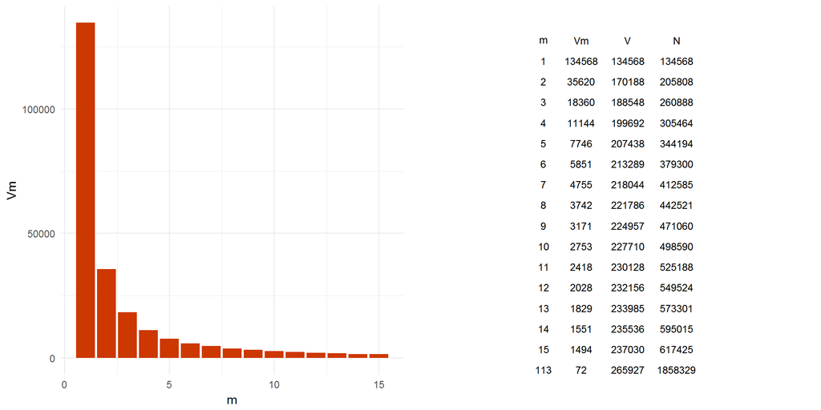

Figure 1: Frequency spectrum for blogs register

##### Applying Zipf’s Law to Lexical Size Problem

The next step in the analysis was to ascertain the degree to which Zipfs law, in its classic form, could be applied as above to determine optimal lexical size.

##### Zipfian Distribution Goodness-of-Fit

The Zipf Plot, which relates log rank to log frequency, provides a good visual indicator of goodness-of-fit. The following plots graphically characterize goodness-of-fit for each register.

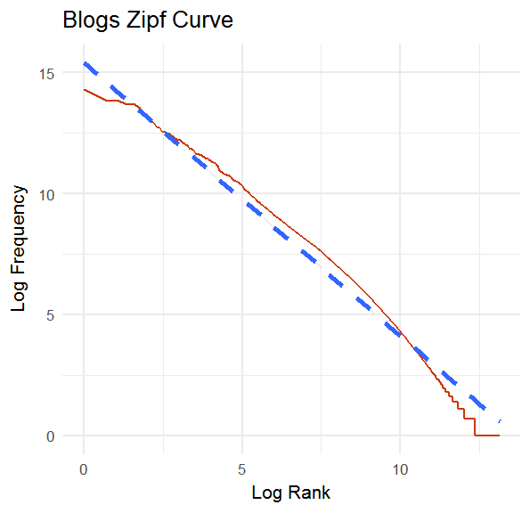

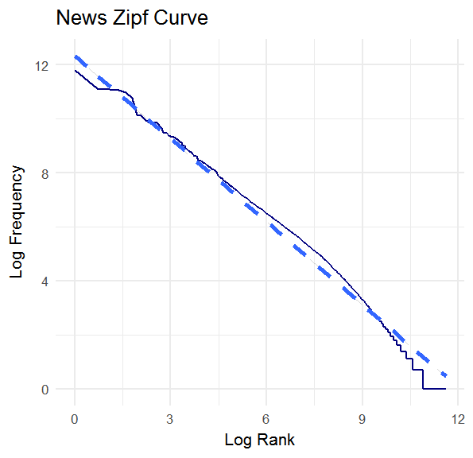

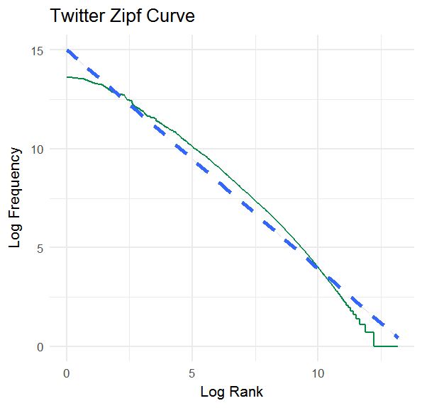

Figure 2: Zipfian Distribution Goodness of Fit

The curvilinear line shapes indicate systematic variation from a Zipfian distribution. The following residual plots confirm problems with goodness-of-fit.

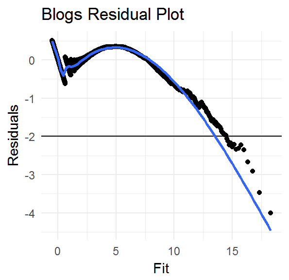

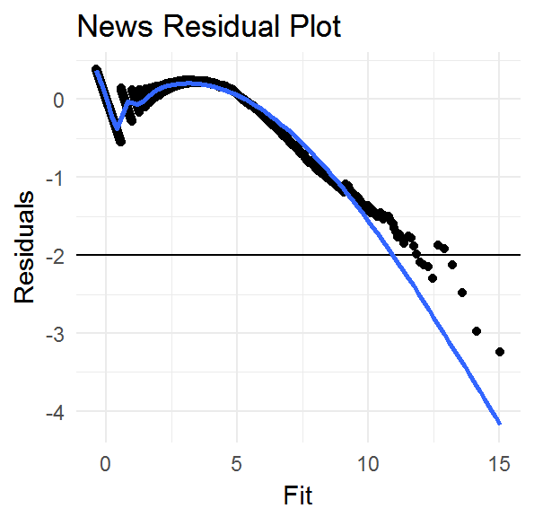

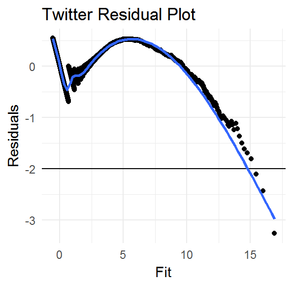

Figure 3: Zipf Residual Plots

##### Zipf-Mandelbrot Model

$$f(r) = \frac{1}{(r+\beta)^\alpha}$$
By “shifting” the rank by an amount β, the Zipf-Mandelbrot (ZM) formulation more closely fits the frequency distribution in language [Zipf (1936); Zipf49; Mandelbrot1953; Mandelbrot61]. Using the zipfR package (Evert 2015), ZM models were independently fit against each register of the corpus. Parameters $\alpha$ and $\beta$ were estimated as follows:

Table 4: Zipf-Mandelbrot Model Parameters by Register

| Register | Alpha | Beta |
| --- | --- | --- |
| Blogs | 0.5538 | 0.0012 |
| News | 0.5572 | 0.0014 |
| Twitter | 0.5933 | 0.0019 |

**Frequency Spectra** Frequency spectra are the essential data structures used to estimate the required lexical vocabulary size to meet a language coverage target. Expected frequency spectra were estimated using the ZM model and are juxtaposed against the observed word frequency distributions from the corpus.

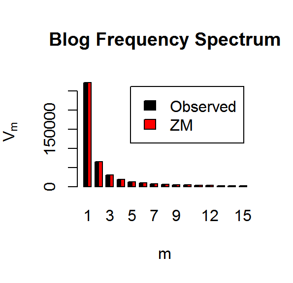

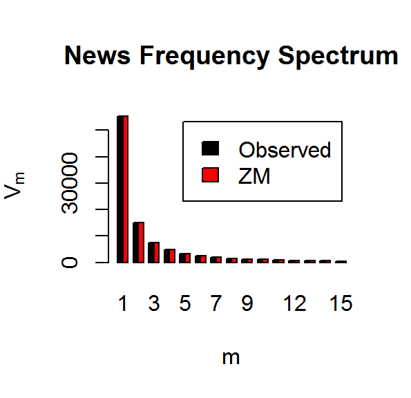

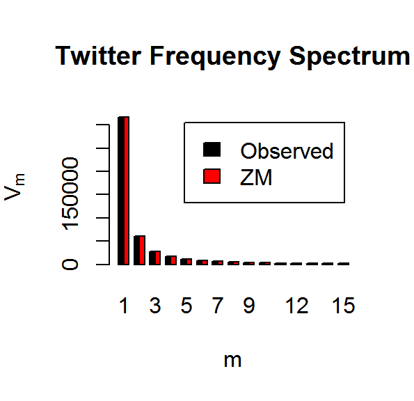

Figure 4: Zipf-Mandelbrot Expected vs. Observed Frequency Spectra

The observed and expected frequency spectra appear to fit very well. Next, the observed (smoothed) and extrapolated vocabulary growth curves are evaluated for fit.

**Vocabulary Growth Curves** Vocabulary growth curves (VGCs) relate vocabulary size $V$ to sample size $N$. Expected VGCs were extrapolated using the ZM model from observed VGCs and are plotted vis-a-vis smoother (interpolated) observed VGCs.

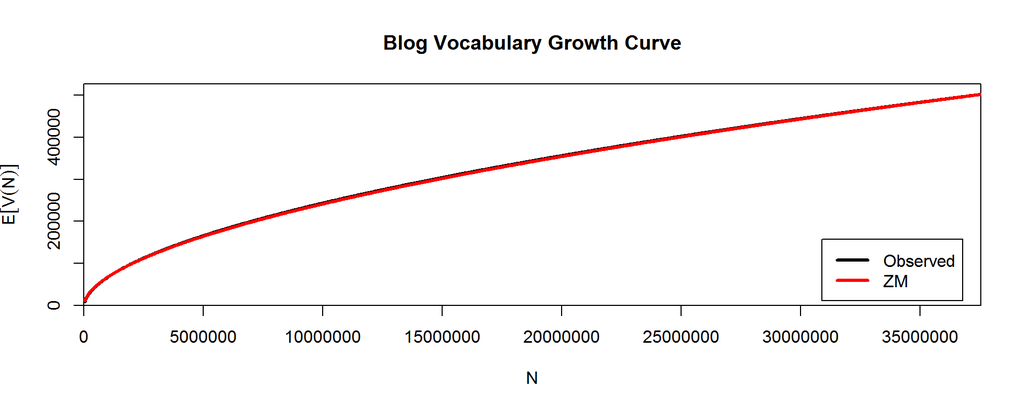

Figure 5: Zipf-Mandelbrot Expected vs. Observed Vocabulary Growth Curves (Blogs)

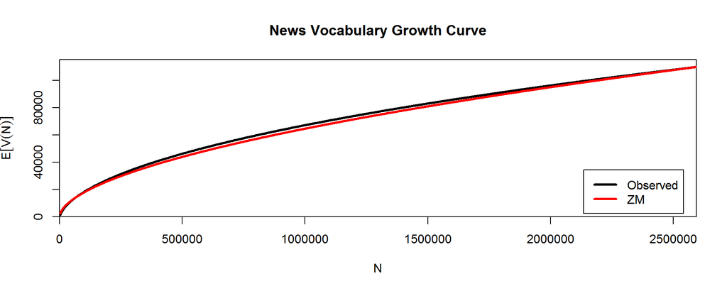

Figure 6: Zipf-Mandelbrot Expected vs. Observed Vocabulary Growth Curves (News)

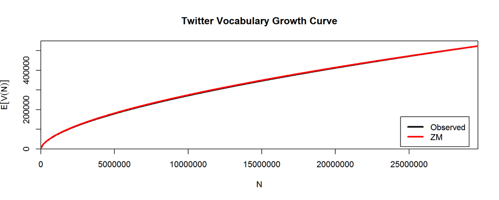

Figure 7: Zipf-Mandelbrot Expected vs. Observed Vocabulary Growth Curves (Twitter)

Both spectra and vocabulary growth curves fit the data reasonably well. Now, the lexical size can be estimated.

##### Lexical Size Estimate

Traversing the frequency spectra, the vocabulary size required for a certain level of coverage was ascertained. Cross-referencing vocabulary size on the vocabulary curve provided the number of tokens associated with the vocabulary size estimates. The following plot relates lexical coverage to sample size.

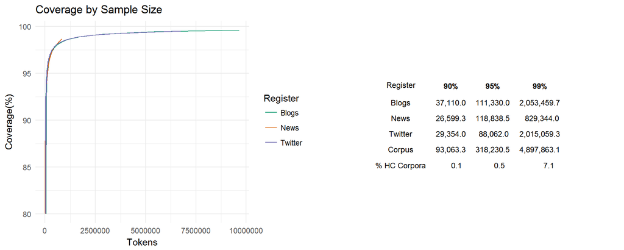

Figure 8: Lexical Coverage by Sample Size

#### Lexical Feature Analysis

Corpus representativeness, Biber argues, also depends upon “the extent to which it contains the range of linguistic distributions in the population” (Biber 1993). Based upon Douglas Biber’s Representativeness in Corpus Design (Biber 1993), this analysis examines the distribution of lexical features to determine optimal lexical size in terms of the size of the sampling unit, the number of sampling units in the overall lexical resource as well as the stratified representation of each register within the corpus.

##### Sampling Unit

According to Biber (1993), each sampling unit should represent the range of linquistic characteristics in the text. To determine sampling unit size, the corpus was split into 50 pairs of 100, 500, 1000, and 2000 word texts. Chi-squared tests compared the distributions of 12 selected lexical features between the pairs of texts. The lexical features studied were chosen from different functional and grammatical classes which represented a range of distributions across texts. If large differences were found between the two pairs of samples, the sample size did not adequately represent the overall linguistic characteristics of the text.